# PTMC_usage

David Hodgson

```r
#devtools::install(ptmc) install if needed
library(ptmc)
library(tidyverse)
library(coda)
```

# Parallel Tempering Monte Carlo

## Model

The example model is taken from Ben Lambert’s fantastic book, “A Student’s Guide to Bayesian Statistics,” [Questions 13.3](https://benlambertdotcom.files.wordpress.com/2018/08/bayesianbook_problemsanswers_final.pdf#page=124). Breifly, I assume the random count variable $X_t$, the number of mosquitos caught during day $t$, is Poission, such that

$$\begin{equation}
\begin{split}
X_t &\sim \textit{Poisson}(\lambda)\\
\lambda &= 1000 \times \exp(-\mu t)\psi
\end{split}
\end{equation}$$

where $\mu$ is a constant mortality hazard rate and $\psi$ is the daily recapture probability with priors distributions of $\mu \sim \Gamma(2,20)$ and $\psi \sim \textit{Beta}(2, 40)$. The data $x_t$, the number of mosquitos caught on day $t$ is given in the RWM_mosquito.csv file but can be obtained [here](https://benlambertdotcom.files.wordpress.com/2018/08/all_data.zip).

## Implementation

### Create the model

The `model` variable should be a list with three functions, `gen_init`, `eval_lpr`, and `eval_ll` and a vector string with the parameter names used in the calibration, `par_names`.

#### vector string `parnames`

A vector string of the parameter names

#### func `gen_init`

A function which generates the original samples (usually the prior distributions)

- (no arguments)
- @return vector of values

#### func `eval_ll`

A function which generates the log likelihood for a set of parameter values

- @param data, data needed to calcualte the log likelihood
- @param params, parameter values
- @return log likelihood

#### func `eval_lpr`

A fucntion which calcualte the log prior for a set of parameter values

- @param params, parameter values
- @return log prior

```r
# model is a list of three functions
model <- list(

  par_names = c("mu","psi"),

  # Generate the initial step of Markov chain
  gen_init = function() {
    c(rgamma(1, 2, 20), rbeta(1, 2, 40))
  },

  # Evaluate the log prior
  eval_lpr = function(params) {
    if (params[1] < 0 || params[2] < 0 || params[1] > 1 || params[2] > 1)
      return(-Inf)

    lpr <- 0
    lpr <- lpr + log(pgamma( params[1], 2,20))
    lpr <- lpr + log(pbeta( params[2], 2,40))
    lpr
  },

  # Evaluate the log likelihood
  eval_ll = function(data, params) {
    y <- data$y
    mu <- params[1]
    psi <- params[2]
    ll <- 0;
    for (t in 1:length(data$y))
    {
      sum_x = 0
      lambda = 1000*exp(-mu*(t+1))*psi;
      for (i in 1:y[t]){
        sum_x <- sum_x + i
      }
      ll <- ll - lambda + y[t]*log(lambda) - sum_x
    }
    ll
  }
)
```

### Obtain the data

Data used in the likelhood function can be in any format.

```r
dataMos <- read.csv("./RWM_mosquito.csv")
# restructure the data for the log likelihood function
data <-   list(
  time = dataMos$time,
  y = dataMos$recaptured
)
```

### Settings

The settings for the parallel tempering calibrations are summarised here

#### Settings Options

- nrChains, number of independent chains to run
- M, number of dependent chains per chain run (i.e. the number of rungs in the temperature ladder)
- iterations, the number of steps to take in the Markov chain, (including the burn in)
- burn, the number of steps int he burn in (these are discarded)
- thin, thinning of the chain (i.e. =10 means only everything 10th sample is saved)
- consoleUpdates, frequency in which the console updates (i. =100 means every 100th step)
- P, number of parameters
- adap_Cov, whether to include adaptive covariance
- adap_Cov_freq, frquency the adaptive covariance matrix os updated
- adap_Cov_burn, number of steps to take before using the adaptive covariance matrix
- adap_Temp, wheter to include adaptive temperature ladder
- adap_Temp_freq, frequency the adaptive temperature ladder is updated
- Debug, run with debug output

```r
# settings used for the ptmc model (See README)
settings <-  list(
  nrChains = 3,
  M = 10,
  iterations = 10000,
  burn = 1,
  thin = 1,
  consoleUpdates = 100,
  P = 2,
  adap_Cov = TRUE,
  adap_Cov_freq = 1,
  adap_Cov_burn = 1000,
  adap_Temp = TRUE,
  adap_Temp_freq = 1,
  Debug = FALSE
)
```

### Run the model.

```r
post <- ptmc_func(model=model, data=data, settings=settings)
```

## Plot the data

`ptmc_func` returns a list of length two. The first element is `post$mcmc` and is a mcmc or mcmc.list object (from the code package). I can plot these and calcualte convergence diagnostics using coda functions:

```r
# Plot trace plots and posterior distributions for $mcmcriors for a chain i
par(mar = rep(2, 4)) # just for plotting purposes
summary(post$mcmc)
```

```
##
## Iterations = 1:9999
## Thinning interval = 1
## Number of chains = 3
## Sample size per chain = 9999
##
## 1. Empirical mean and standard deviation for each variable,
##    plus standard error of the mean:
##
##        Mean       SD  Naive SE Time-series SE
## mu  0.10032 0.008604 4.968e-05      9.268e-05
## psi 0.04658 0.003363 1.942e-05      3.473e-05
##
## 2. Quantiles for each variable:
##
##        2.5%     25%    50%    75%   97.5%
## mu  0.08331 0.09461 0.1003 0.1060 0.11756
## psi 0.04013 0.04433 0.0465 0.0487 0.05339
```

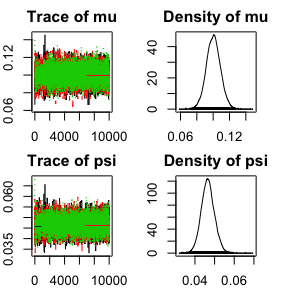

```r
plot(post$mcmc)
```

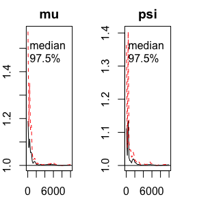

```r
# Plot the Gelman-Rubin diagnostic for the parameters
gelman.plot(post$mcmc)
```

```r
gelman.diag(post$mcmc)
```

```
## Potential scale reduction factors:
##
##     Point est. Upper C.I.
## mu           1          1
## psi          1          1
##
## Multivariate psrf
##
## 1
```

The second element is `post$lpost` and is long table dataframe of the log posterior values. These values can be easily plotted using ggplot2:

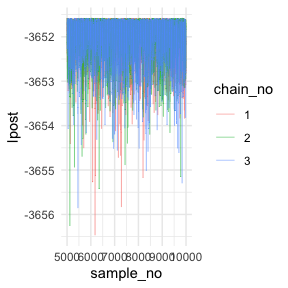

```r
# Plot of the logposterior for the three chains
lpost_conv <- post$lpost %>% filter(sample_no>5000)
logpostplot <- ggplot(lpost_conv, aes(x = sample_no, y = lpost)) +
  geom_line(aes(color = chain_no), size = 0.2, alpha=0.8) +
  theme_minimal()
logpostplot
```